# Patterns ‘stripe’, ‘wave’, ‘crosshatch’, ‘weave’ - Parameters and Examples

```r
suppressPackageStartupMessages({
  library(ggplot2)
  library(ggpattern)
})
```

## Introduction to the ‘stripe’, ‘wave’, ‘crosshatch’, and ‘weave’ patterns

- The ‘stripe’ pattern draws a set of (horizontal) **straight** lines.
- The ‘wave’ pattern draws a set of (horizontal) **wavy** lines.
- The ‘crosshatch’ pattern draws a set of vertical lines on top of a set of horizontal lines.
- The ‘weave’ pattern draws a set of vertical lines interlaced with a set of horizontal lines.
- For more info on these patterns see their `{gridpattern}` documentation:
  - [`help("grid.pattern_stripe", package = "gridpattern")`](https://trevorldavis.com/R/gridpattern/dev/reference/grid.pattern_stripe.html)
  - [`help("grid.pattern_wave", package = "gridpattern")`](https://trevorldavis.com/R/gridpattern/dev/reference/grid.pattern_wave.html)
  - [`help("grid.pattern_crosshatch", package = "gridpattern")`](https://trevorldavis.com/R/gridpattern/dev/reference/grid.pattern_crosshatch.html)
  - [`help("grid.pattern_weave", package = "gridpattern")`](https://trevorldavis.com/R/gridpattern/dev/reference/grid.pattern_weave.html)

## Pattern Parameters

| aesthetic | description | default | possible values |
| --- | --- | --- | --- |
| pattern_colour | Stroke colour | ‘grey20’ | colour |
| pattern_fill | Fill colour | ‘grey80’ | colour |
| pattern_angle | Rotation angle | 30 | angle in degrees |
| pattern_density | Approx. fraction of area the pattern fills | 0.2 | value in range [0, 1] (fraction) |
| pattern_spacing | Spacing between repetitions of pattern | 0.05 | value in `pattern_units` grid units |
| pattern_xoffset | Shift pattern along x axis | 0 | value in `pattern_units` grid units |
| pattern_yoffset | Shift pattern along y axis | 0 | value in `pattern_units` grid units |
| pattern_units | Pattern grid unit | ‘snpc’ | `grid::unit()` unit i.e. ‘snpc’, ‘cm’, and ‘inches’ |
| pattern_alpha | Alpha | NA | value in range [0, 1] or NA |
| pattern_linetype | Stroke linetype | 1 | linetype |
| pattern_size | Stroke linewidth | 1 | linewidth |
| pattern_type | Pattern type | NA | See [wave](https://trevorldavis.com/R/gridpattern/dev/reference/grid.pattern_wave.html) and [weave](https://trevorldavis.com/R/gridpattern/dev/reference/pattern_weave.html) pattern documentation |
| pattern_subtype | Pattern subtype | NA | See [weave](https://trevorldavis.com/R/gridpattern/dev/reference/pattern_weave.html) pattern documentation |
| pattern_frequency | Frequency | 0.1 | Frequency of waves in ‘wave’ pattern |

There are also a number of parameters for extra control of legend sizing and aspect ratio adjustments. See the ‘Pattern Parameters - Common’ for more information.

## Data

Standard data for all the example plots

```r
df <- data.frame(trt = c("a", "b", "c"), outcome = c(2.3, 1.9, 3.2))
df
```

```
#>   trt outcome
#> 1   a     2.3
#> 2   b     1.9
#> 3   c     3.2
```

## Vanilla ggplot2

[figure not shown]

```r
ggplot(df, aes(trt, outcome)) +
  geom_col(aes(fill=trt),colour='black') +
  theme_bw() +
  labs(title = "Plain ggplot2")
```

## Use the `{ggpattern}` geom

- Use `ggpattern::geom_col_pattern()` instead of `ggplot2::geom_col()`.
- Set `pattern = 'stripe'`
- Default legends in `ggplot2` are usually too small to show off an example of the pattern, so it will usually be necessary to increase the key size.

[figure not shown]

```r
ggplot(df, aes(trt, outcome)) +
  geom_col_pattern(aes(fill=trt),colour='black',
                   pattern='stripe') +
  theme_bw() +
  labs(title = "ggpattern") +
  theme(legend.key.size = unit(1.5, 'cm'))
```

## Mixing patterns

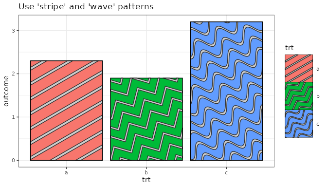

```r
ggplot(df, aes(trt, outcome)) +
  geom_col_pattern(aes(fill=trt, pattern=trt, pattern_type=trt),
                   colour='black', pattern_key_scale_factor=0.5,
                   pattern_spacing=0.7, pattern_frequency=0.7, pattern_units='cm') +
  theme_bw() +
  labs(title = "Use 'stripe' and 'wave' patterns") +
  theme(legend.key.size = unit(1.5, 'cm')) +
  scale_pattern_manual(values=c('stripe', 'wave', 'wave')) +
  scale_pattern_type_manual(values=c(NA, 'triangle', 'sine'))
```

## The Density Aesthetic

The aesthetic `pattern_density` roughly corresponds to the fraction of the filled area which should be covered by the pattern.

In the following plot the density of striping is increased to 50% of the fill area.

[figure not shown]

```r
ggplot(df, aes(trt, outcome)) +
  geom_col_pattern(
    aes(fill=trt, pattern=trt),
    colour          = 'black',
    pattern_density = 0.5
  ) +
  theme_bw() +
  labs(title = "Fixed density of 0.5 (50% of the fill area)") +
  scale_pattern_manual(values=c('stripe', 'crosshatch', 'weave')) +
  theme(legend.key.size = unit(1.5, 'cm'))
```

## Weave types

The ‘weave’ pattern supports a rich set of weave types and subtypes including irregular ‘matt’, ‘twill’ (including ‘herringbone’ and ‘zigzag’ variations), and ‘satin’ weaves . See the [weave](https://trevorldavis.com/R/gridpattern/dev/reference/pattern_weave.html) pattern documentation for more information.

[figure not shown]

```r
ggplot(df, aes(trt, outcome)) +
  geom_col_pattern(
    aes(pattern_fill2=trt, pattern_type=trt),
    pattern = 'weave',
    colour          = 'black',
    pattern_density = 1.0,
    pattern_fill = 'grey',
    pattern_key_scale_factor = 0.5,
  ) +
  theme_bw() +
  labs(title = "Some 'weave' types") +
  scale_pattern_type_manual(values=c('plain', 'twill', 'satin')) +
  theme(legend.key.size = unit(1.5, 'cm'))
```

## The Density Aesthetic as a Mapped Aesthetic

[figure not shown]

```r
ggplot(df, aes(trt, outcome)) +
  geom_col_pattern(
    aes(fill = trt, pattern_density = trt),
    colour          = 'black',
    pattern         = 'stripe'
  ) +
  theme_bw() +
  labs(title = "Aesthetic Mapping of 'trt' to Density") +
  theme(legend.key.size = unit(1.5, 'cm'))
```

## The Density Aesthetic as a Mapped Aesthetic with Manual Scale

`scale_pattern_density_manual()` can be used to manually control how the variable is mapped to the density.

[figure not shown]

```r
ggplot(df, aes(trt, outcome)) +
  geom_col_pattern(
    aes(fill = trt, pattern_density = trt),
    colour          = 'black',
    pattern         = 'stripe'
  ) +
  theme_bw() +
  labs(title = "Aesthetic Mapping of 'trt' to Density") +
  theme(legend.key.size = unit(1.5, 'cm')) +
  scale_pattern_density_manual(values = c(a = 0.1, b=0.3, c=0.5))
```

## The Spacing Aesthetic as a Mapped Aesthetic

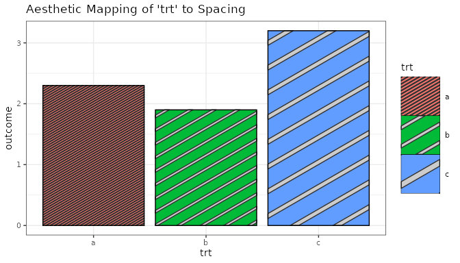

```r
ggplot(df, aes(trt, outcome)) +
  geom_col_pattern(
    aes(fill = trt, pattern_spacing = trt),
    colour          = 'black',
    pattern         = 'stripe'
  ) +
  theme_bw() +
  labs(title = "Aesthetic Mapping of 'trt' to Spacing") +
  theme(legend.key.size = unit(1.5, 'cm'))
```

## The Fill Aesthetic as a Mapped Aesthetic

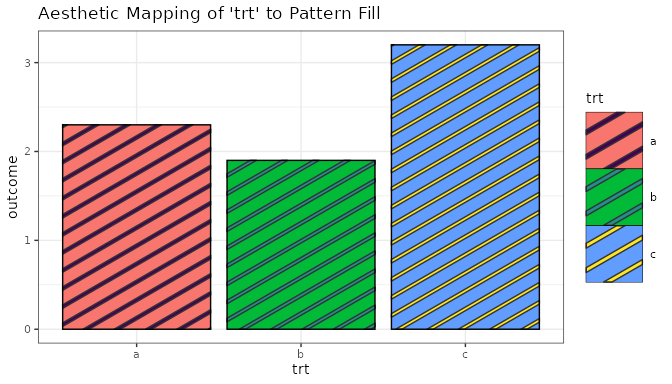

```r
ggplot(df, aes(trt, outcome)) +
  geom_col_pattern(
    aes(fill = trt, pattern_fill = trt),
    colour          = 'black',
    pattern         = 'stripe'
  ) +
  theme_bw() +
  labs(title = "Aesthetic Mapping of 'trt' to Pattern Fill") +
  scale_pattern_fill_viridis_d() +
  theme(legend.key.size = unit(1.5, 'cm'))
```